# バブルマップによる地価の可視化

神奈川県の例

[岩田真一郎](https://shinichiro-iwata.github.io/)（ [神奈川大学経済学部](https://www.econ.kanagawa-u.ac.jp/)）

2022-06-06作成，2025-02-12改訂

# 目的

地価公示（ポイント）の大きさを変えることにより，地価が高い箇所を強調表現（地価が低い箇所は抑制表現）．ポイントはバブル（泡）と言い換えられ，バブルを使った図はバブルチャートとよばれる．地図の場合はバブルマップとよぶ．

パッケージ：`sf`，`tidyverse`

```r
library(sf)
library(tidyverse)
```

# 地価公示の可視化

[ポイントデータによる地価の可視化](https://shinichiro-iwata.github.io/geospatial-data-visualization/point-data-visualization.html)で作成した図3：神奈川県地価（2022年）を再現．

**シェープファイルのダウンロード**

- [国土数値情報ダウンロードサービス](https://nlftp.mlit.go.jp/ksj/) > 行政区域（ポリゴン） > 神奈川県 > 令和3年
- [国土数値情報ダウンロードサービス](https://nlftp.mlit.go.jp/ksj/) > 地価公示（ポイント） > 神奈川県 > 「神奈川県」データのダウンロード > 世界測地系 令和4年
  - ダウンロードしたZIPファイルは同じフォルダ（ディレクトリ）に納め，ZIPファイルを選択 > 右クリック > すべて展開 > 展開先の選択とファイルの選択 > 展開を実行する．展開後は最初にダウンロードしたZIPファイルを削除．
  - シェープファイルの読込（`read_sf`）：行政区域のオブジェクト名を`Kanagawa_map`，地価公示のオブジェクト名を`Kanagawa_lp`とする．

```r
Kanagawa_map<-
  read_sf('N03-20210101_14_GML/N03-21_14_210101.shp')

Kanagawa_lp<-read_sf('L01-22_14_GML/L01-22_14.shp')
```

**データのソート**

地価（`L01_006`）が高いポイントの色が上にくるよう順番を変更（`arrange`）．

- データ名は`Kanagawa_lp`のまま．

```r
Kanagawa_lp %>%
  arrange(L01_006) ->
  Kanagawa_lp
```

**再現図形**

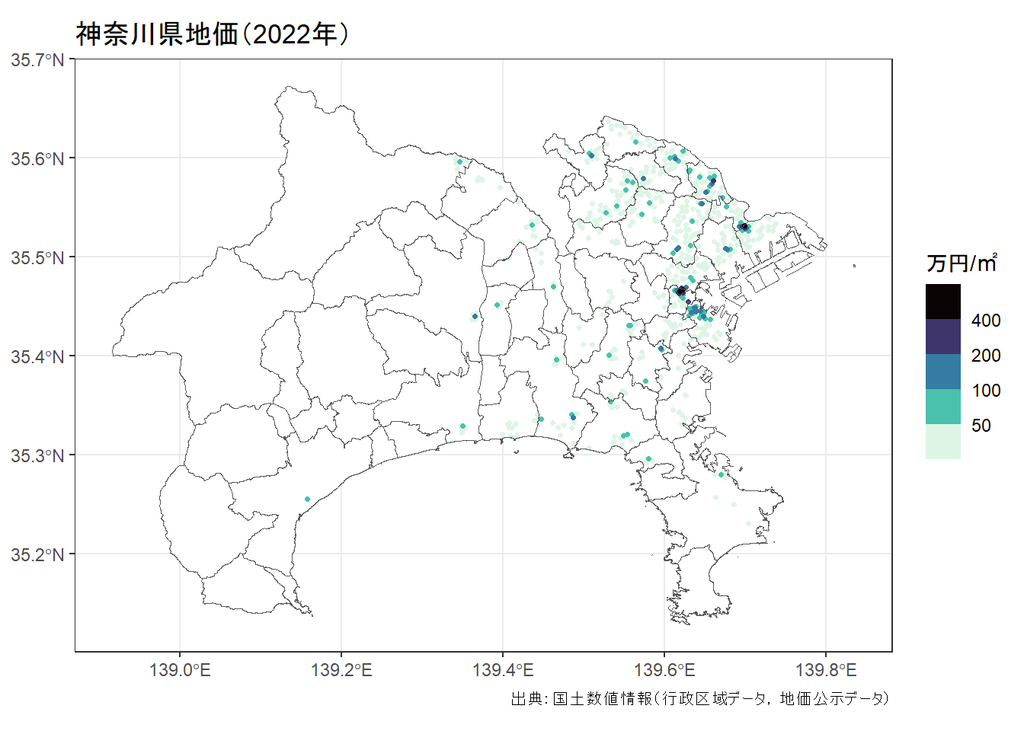

```r
my_breaks <- c(50, 100, 200, 400)

#神奈川県地価の可視化
ggplot()+
  geom_sf(data=Kanagawa_map, fill="white")+
  geom_sf(data=subset(Kanagawa_lp, L01_006/10000>=25),
          aes(color=L01_006/10000),
          size=0.9)+
  scale_color_viridis_b(option="G", direction=-1,
                        trans="log10",
                        breaks=my_breaks)+
  geom_sf(data=Kanagawa_map, fill="NA")+
  labs(color="万円/㎡",
       caption="出典：国土数値情報（行政区域データ，地価公示データ）")+
  ggtitle("神奈川県地価（2022年）")+
  theme_bw()
```

# バブルマップによる可視化

地価公示ポイント（バブル）の大きさを変えるために，`aes(size)`を利用する．これを活かすために，地価公示ポイント（`x`軸が経度，`y`軸が緯度）の変数を作成．

- 地価公示ポイントは緯度経度により表現される．この情報は列名`geometry`にすでに納められている．
  - `select()`：列の抽出．
  - オブジェクト名（`Kanagawa_lp1`）を変更して，`head()`で中身を確認．

```r
#geometry抽出，データ名変更
Kanagawa_lp1 <- Kanagawa_lp %>%
  select(geometry)

#最初の6行
Kanagawa_lp1 %>%
  head()
```

| geometry |
| --- |
| POINT (139.6507 35.20473) |
| POINT (139.2251 35.41038) |
| POINT (139.1146 35.25959) |
| POINT (139.3062 35.46262) |
| POINT (139.247 35.3452) |
| POINT (139.4259 35.40653) |

- ↑の列の中身（成分）を見ると，緯度経度の両方が含まれている．
  - `st_coordinates()`：座標を取得するように指示．ここでは，括弧内の1番目の数値（経度）を`x`，2番目の数値（緯度）を`y`とするように指示．
  - オブジェクト名は`Kanagawa_lp`のまま．
  - 中身を確認するため，`select()`を用いて必要な列の抽出．
  - オブジェクト名（`Kanagawa_lp2`）を変更して，`head()`で中身を確認．

```r
#もとのデータで作業
Kanagawa_lp <- Kanagawa_lp %>%
  mutate(x=st_coordinates(geometry)[, 1],
         y=st_coordinates(geometry)[, 2])

#geometry，緯度経度の抽出，データ名変更
Kanagawa_lp2 <-
  Kanagawa_lp %>%
  select(geometry, x, y)

#最初の6行
Kanagawa_lp2 %>%
  head()
```

| geometry | x | y |
| --- | --- | --- |
| POINT (139.6507 35.20473) | 139.6507 | 35.20473 |
| POINT (139.2251 35.41038) | 139.2251 | 35.41038 |
| POINT (139.1146 35.25959) | 139.1146 | 35.25959 |
| POINT (139.3062 35.46262) | 139.3062 | 35.46262 |
| POINT (139.247 35.3452) | 139.2470 | 35.34520 |
| POINT (139.4259 35.40653) | 139.4259 | 35.40653 |

- `aes(x=x, y=y)`：`x`軸を↑で作成した`x`の値を，`y`軸を↑で作成した`y`の値を使うように指示．これにより，泡（地価ポイント）の位置（緯度経度）が確定する．
- `aes(color=, size=)`で泡（地価ポイント）の色（`color`）と大きさ（`size`）を指示．
  - `aes(size=L01_006/10000)`：泡（地価ポイント）の大きさを2022年の地価（`L01_006`）の高低で表現できるようにに指示．
  - ここでは単位を万円／㎡にするために`L01_006`を1万（`10000`）で割る．
  - `alpha`で泡の色の透明度を調整．
- `guide="legend"`：凡例を制御．指示しない場合，`color`と`size`の凡例が別々に表現される．
- `scale_size_area(max_size=7)`で泡の大きさの最大値を指示．
- `x=""`，`y=""`を記すことで，`x`軸と`y`軸のラベル削除．

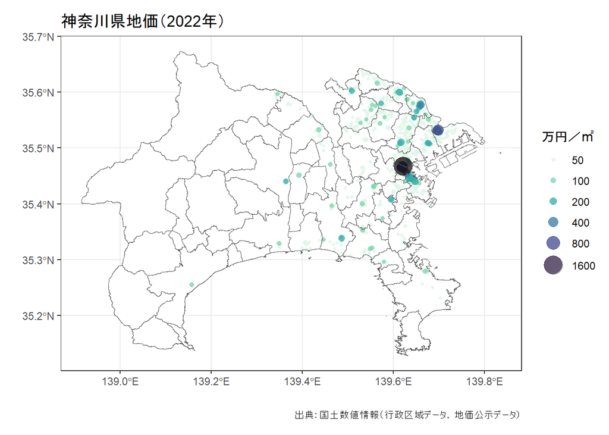

```r
my_breaks <- c(50, 100, 200, 400, 800, 1600)

#神奈川県地価の可視化
ggplot()+
  geom_sf(data=Kanagawa_map, fill="white")+
  geom_point(data=subset(Kanagawa_lp, L01_006/10000>=25),
             aes(x=x, y=y,
                 color=L01_006/10000,
                 size=L01_006/10000),
             alpha=0.75)+
  scale_color_viridis_b(option="G", direction=-1,
                        trans="log10",
                        breaks=my_breaks,
                        guide="legend")+
  scale_size_area(max_size=7,
                  breaks=my_breaks)+
  geom_sf(data=Kanagawa_map, fill="NA")+
  labs(color="万円／㎡", size="万円／㎡",
       x="", y="",
       caption="出典：国土数値情報（行政区域データ，地価公示データ）")+
  ggtitle("神奈川県地価（2022年）")+
  theme_bw()
```

# 川崎市の例

神奈川県の行政区域データ及び地価公示データから川崎市だけを抜き出し，可視化．

- 行政区域については`N03_003`から`川崎市`を識別．
- 地価については`L01_022`に川崎市の行政区域のコード（`14131`～`14137`）が示されている．

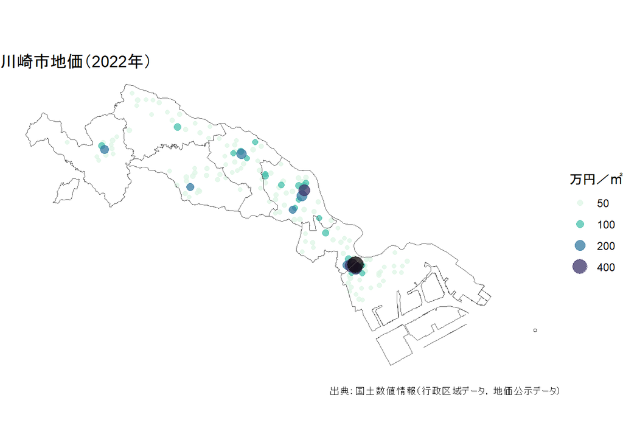

```r
my_breaks <- c(50, 100, 200, 400)

#川崎市地価の可視化
ggplot()+
  geom_sf(data=subset(Kanagawa_map, N03_003=="川崎市"),
          fill="white")+
  geom_point(data=subset(Kanagawa_lp, L01_006/10000>=25 &
                        L01_022>=14131 & L01_022<=14137),
             aes(x=x, y=y,
                 color=L01_006/10000,
                 size=L01_006/10000),
             alpha=0.75)+
  scale_color_viridis_b(option="G", direction=-1,
                        trans="log10",
                        breaks=my_breaks,
                        guide="legend")+
  scale_size_area(max_size=6,
                  breaks=my_breaks)+
  geom_sf(data=subset(Kanagawa_map, N03_003=="川崎市"),
          fill="NA")+
  labs(color="万円／㎡", size="万円／㎡",
       caption="出典：国土数値情報（行政区域データ，地価公示データ）")+
  ggtitle("川崎市地価（2022年）")+
  theme_void()
```

**参考ウェブサイト**

- [Bubble map with ggplot2](https://r-graph-gallery.com/330-bubble-map-with-ggplot2.html) – [the R Graph Gallery](https://r-graph-gallery.com/)

**Rによる地理空間データの可視化**

- チュートリアル[ホーム](https://shinichiro-iwata.github.io/geospatial-data-visualization/)